# ABI with R project report

# Task1

```r
# Loading churn data from "C50" package
# install.packages('C50')
library(C50)
data(churn)

# Overall churn rate
table(churnTrain$churn)
```

```
##
##  yes   no
##  483 2850
```

```r
# Descriptive analysis using ggplot
# install.packages('ggplot2')
library(ggplot2)

churnTrain$churn_flag <- ifelse(churnTrain$churn == 'yes',1,0)
data1 <- aggregate(churnTrain$churn_flag,by=list(state=churnTrain$state),FUN = mean)
data1 <- data.frame(state=data1$state,churnrate=data1$x)

data2 <- aggregate(churnTrain$churn,by=list(state=churnTrain$state),FUN = length)
data2 <- data.frame(state=data2$state,count=data2$x)
```

The overall churn rate is 14.49%

Descriptive Analysis:

Graph 1:

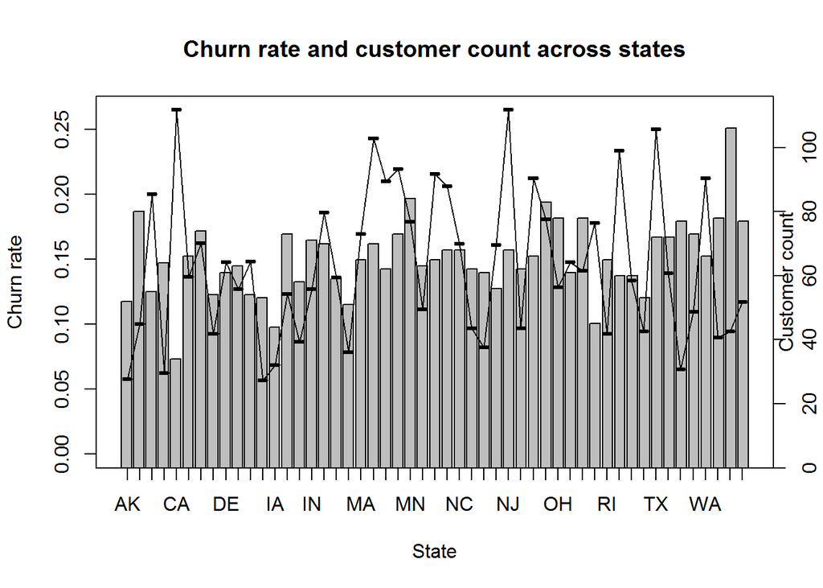

```r
# Graph1
# plot.new()
barplot(data2$count, axes=F,ylim=c(0,max(data2$count+10)))
axis(side=4,ylim=c(0,max(data2$count)))
mtext("Customer count",side=4)
par(new=TRUE)
plot(x=data1$state, y=data1$churnrate,main="Churn rate and customer count across states",xlab="State",ylab="Churn rate",axes=T,ylim=c(0,max(data1$churnrate)))
lines(x=data1$state, y=data1$churnrate,axes=T,ylim=c(0,max(data1$churnrate)))
```

The above graph shows the churn rate on the primary axis and number of customers on the secondary axis for each state. We can see fromt he graph that there are states like CA,NJ etc whose curn rate is greater than 20%. These shouls be the areas of focus while implementing a churn analysis plan.

Graph 2:

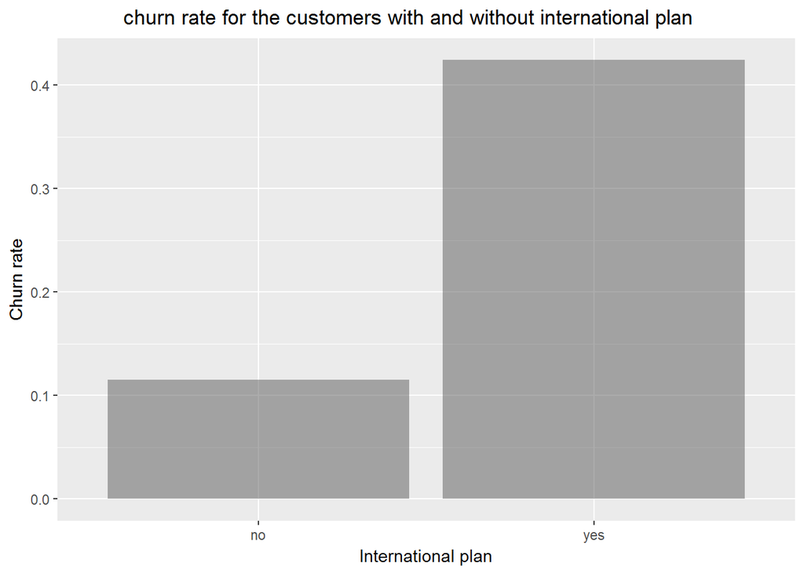

```r
# Graph2
# plot.new()
data1 <- aggregate(x = churnTrain$churn_flag,by=list(Interntional_plan=churnTrain$international_plan),FUN = mean)
data1 <- data.frame(Int_plan = data1$Interntional_plan,churnrate=data1$x)

ggplot(data1, aes(x=data1$Int_plan, y=data1$churnrate))+geom_bar(stat="identity", alpha=0.5) + xlab("International plan") + ylab("Churn rate") + labs(title= "           churn rate for the customers with and without international plan")
```

The above graph shows a comparision of churn rates between two segments. The left barplot is the churn rate among the customers who donot have interntional plan. The second bar is for the customers who have international plan. 1. We can see from the graph that the churn rate for the customers with internationla plan is very high(42.4%) when compared to the customers with no international plan. Also the churn in this segment is 28.3% percentage out of total churn which is a significant portion.

2. Also in Graph 1 we see there is high churn rate int he states like CA, TX, NJ where there is a high percentage of foreign citizens. The reason for these customers to churn could be that they are not satisfied with the international calling charges or services

Graph 3

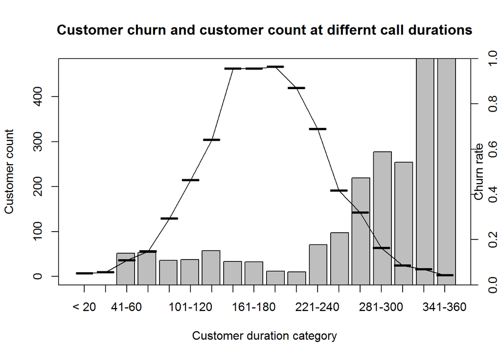

```r
# Graph3
# plot.new()
df1<-NULL
df1 <- transform(churnTrain, group=cut(churnTrain$total_day_minutes,
        breaks=seq(0,360,20),
        labels=c('< 20','21-40','41-60','61-80','81-100','101-120','121-140','141-160','161-180','181-200',
                 '201-220','221-240','241-260','261-280','281-300','301-320','321-340','341-360')))

data1 <- aggregate(df1$churn_flag,by=list(group=df1$group),FUN = mean)
data1 <- data.frame(group=data1$group,churnrate=data1$x)

data2 <- aggregate(df1$churn,by=list(group=df1$group),FUN = length)
data2 <- data.frame(group=data2$group,count=data2$x)


barplot(data1$churnrate, axes=F,ylim=c(0,max(data1$churnrate)))
axis(side=4,ylim=c(0,max(data2$count)))
mtext("Churn rate",side=4)
par(new=TRUE)
plot(x=data2$group, y=data2$count,main="Customer churn and customer count at differnt call durations",xlab="Customer duration category",ylab="Customer count",axes=T,ylim=c(0,max(data2$count)))
lines(x=data2$group, y=data2$count,axes=T,ylim=c(0,max(data2$count)))
```

The above plot shows the distribution plot of the customer total day call minutes on the primary axis. The bar plot on the secondary axis shows the churn rate of the customers based on their total duration in day calls.

1. This graph shows that the customers who have “higher duration for the day calls” have higher percentage of churn rate when compared to the other duration buckets. This can be seen at the extreme right distribution in the graph. 8% of the customers fall into this high day calls duration segment. There is a possibility these customers might chhurn in future

# Task 2:

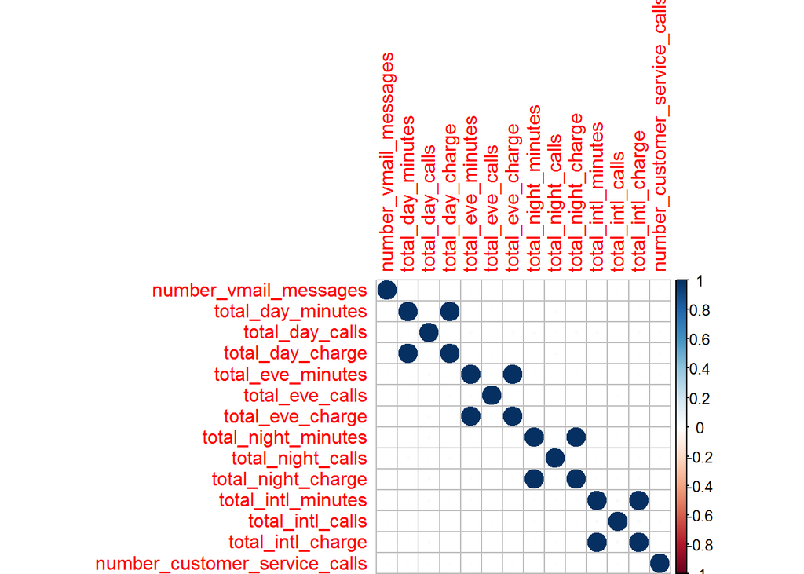

```r
# install.packages('corrplot')
library(corrplot)
my_data <- churnTrain[,seq(6,19,1)]
z <- cor(my_data)
corrplot(z,method='circle')
```

The above correlation matrix shows that there are some variables which are correlated as high as 0.99. This might cause multicollinearity in the models built further. This should be take caren of when the prediction models are built

Sice we want to understand the driveres that cause customer churn, doing a logistic regression would be appropriate on this data. To avoid Variace Inflation Factor, certain variables are removed fromt the model.

Logistic regression on this data gave the following results:

```r
model_data <- churnTrain
model_data[ ,c('total_day_charge','total_eve_charge','total_night_charge','total_intl_charge',
               'total_day_calls','total_eve_calls','total_night_calls','churn')] <- NULL
model <- glm(churn_flag ~.,family=binomial(link='logit'),data=model_data)
summary(model)
```

```
##
## Call:
## glm(formula = churn_flag ~ ., family = binomial(link = "logit"),
##     data = model_data)
##
## Deviance Residuals:
##     Min       1Q   Median       3Q      Max
## -1.9210  -0.5012  -0.3126  -0.1679   3.0905
##
## Coefficients:
##                                Estimate Std. Error z value Pr(>|z|)
## (Intercept)                   -9.188843   0.848940 -10.824  < 2e-16 ***
## stateAL                        0.356152   0.762271   0.467 0.640339
## stateAR                        0.939554   0.751170   1.251 0.211012
## stateAZ                        0.115059   0.844047   0.136 0.891569
## stateCA                        1.867943   0.781768   2.389 0.016877 *
## stateCO                        0.664295   0.761330   0.873 0.382910
## stateCT                        1.041330   0.723838   1.439 0.150257
## stateDC                        0.733022   0.806362   0.909 0.363325
## stateDE                        0.772569   0.748477   1.032 0.301984
## stateFL                        0.636844   0.758662   0.839 0.401228
## stateGA                        0.720139   0.774934   0.929 0.352739
## stateHI                       -0.200420   0.896872  -0.223 0.823173
## stateIA                        0.265974   0.901440   0.295 0.767953
## stateID                        0.931957   0.744955   1.251 0.210925
## stateIL                       -0.160534   0.829200  -0.194 0.846489
## stateIN                        0.501593   0.750440   0.668 0.503879
## stateKS                        1.101061   0.728491   1.511 0.130679
## stateKY                        0.831268   0.764070   1.088 0.276619
## stateLA                        0.599701   0.833962   0.719 0.472081
## stateMA                        1.204365   0.740875   1.626 0.104035
## stateMD                        1.165800   0.715228   1.630 0.103108
## stateME                        1.376924   0.725885   1.897 0.057842 .
## stateMI                        1.421392   0.712082   1.996 0.045922 *
## stateMN                        1.192801   0.713850   1.671 0.094733 .
## stateMO                        0.625165   0.773775   0.808 0.419124
## stateMS                        1.387093   0.726811   1.908 0.056331 .
## stateMT                        1.871177   0.716002   2.613 0.008965 **
## stateNC                        0.654210   0.750613   0.872 0.383444
## stateND                        0.181105   0.795585   0.228 0.819928
```

[output cut: 29 more lines]

```
## total_eve_minutes              0.007700   0.001183   6.509 7.55e-11 ***
## total_night_minutes            0.003957   0.001150   3.441 0.000580 ***
## total_intl_minutes             0.083999   0.021080   3.985 6.75e-05 ***
## total_intl_calls              -0.090466   0.025674  -3.524 0.000426 ***
## number_customer_service_calls  0.534971   0.040861  13.092  < 2e-16 ***
## ---
## Signif. codes:  0 '***' 0.001 '**' 0.01 '*' 0.05 '.' 0.1 ' ' 1
##
## (Dispersion parameter for binomial family taken to be 1)
##
##     Null deviance: 2758.3  on 3332  degrees of freedom
## Residual deviance: 2073.9  on 3270  degrees of freedom
## AIC: 2199.9
##
## Number of Fisher Scoring iterations: 6
```

```r
# install.packages('car')
library(car)
vif(model)
```

```
##                                    GVIF Df GVIF^(1/(2*Df))
## state                          1.358026 50        1.003065
## account_length                 1.030047  1        1.014912
## area_code                      1.061229  2        1.014968
## international_plan             1.147291  1        1.071116
## voice_mail_plan               16.316978  1        4.039428
## number_vmail_messages         16.246702  1        4.030720
## total_day_minutes              1.074450  1        1.036557
## total_eve_minutes              1.055865  1        1.027553
## total_night_minutes            1.035570  1        1.017630
## total_intl_minutes             1.029865  1        1.014823
## total_intl_calls               1.029270  1        1.014529
## number_customer_service_calls  1.134656  1        1.065202
```

```r
prediction <- predict(model,churnTest,type='response')
Final_pred <- data.frame(pred=prediction, actual=as.character(churnTest$churn))
Final_pred$bin_pred <- ifelse(Final_pred$pred>0.5,'yes','no')

Final_pred$comp <- ifelse(Final_pred$actual == Final_pred$bin_pred,"Match","Dont Match")
```

Mitigations: 1.Special offers should be given to the customers who have high call durations irrespective of the time of day 2.International calling services ahould include more benifits as per the customer needs 3.The customer service calls should be taken more seriously and their issues should be given the best possible solution

# Task 3

While the logistic regression model results revealed some drivers which might be causing the churn, the tree based models will give the best possible predictions about the customers who can churn.

In order to ensure the best possible predictions, three tree based models are fit and model with best forecast accuracy is considered to predict the churn and futher address the solution. The models used for comparision are CART, Bagged model and Randome Forest Model. The following code gives the model predictions and accuracy for all the three models

```r
# Function to find accuracy of a model
Acc_fun <- function(model_output)
{
  pred <- predict(model_output,churnTest)
  Final_pred <- data.frame(pred, actual=as.character(churnTest$churn))
  Final_pred$bin_pred <- ifelse(Final_pred$pred>0.5,'yes','no')
  Final_pred$compare <- ifelse(Final_pred$actual == Final_pred$bin_pred,"Match","Dont Match")
  Accuracy <- table(Final_pred$compare)[2]/nrow(Final_pred)

  return(list(Accuracy,Final_pred))
}

# Classification tree
# install.packages('rpart')
library(rpart)
cartModel <- rpart(churn_flag~., data = model_data)
Accuracy_CT <- Acc_fun(model_output = cartModel)


# Bagged decision tree
# install.packages('ipred')
library(ipred)
bag_model <- bagging(churn_flag~., data = model_data)
Accuracy_Bag <- Acc_fun(model_output = bag_model)


# Random Forest
# install.packages('randomForest')
library(randomForest)
RF_model <- randomForest(churn_flag~., data = model_data)
RF_output <- Acc_fun(model_output = RF_model)

Accuracy_CT[1]
```

```
## [[1]]
##     Match
## 0.9376125
```

```r
Accuracy_Bag[1]
```

```
## [[1]]
##     Match
## 0.9388122
```

```r
RF_output[1]
```

```
## [[1]]
##     Match
## 0.9460108
```

Out of all the three models, Randome Forest method has given the best accuracy. So RF model is considered for further analysis.

Financials of the plan: Customer should be made aware of this offer to stop him from leaving. For this, they should should be targeted through e mails and postal mails. The company should also design the content of the mails, which contains the message to be comunicated to the customers.The mails are sent to the customers once in two weeks, to make sure, they are aware of this offer.

Assumptions: 1. The response rate for this campaign will be 60% 2. This campaign will stop the customers from churing for atleast 6 months 3. The revenue from each customer is the average value of the charges from all the call types(day calls, eve calls, nigh calls) in the data

Estimated costs are as follows:

It is most profitable for the company to target all the customers whose probability is above 0.27

The estimated profit for six months is atleast $1819.4*6 = $10,916

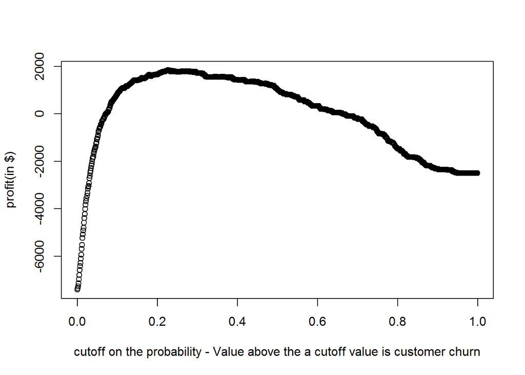

```r
RF_pred_data <- RF_output[[2]]

#
sequence <- seq(0,1,0.001)
# i <- 5
breakeven_data <- data.frame()
# colnames(breakeven_data) <- c("cutoff","profit")
for (i in 1:1000)
{
  check <- RF_pred_data[RF_pred_data$pred>sequence[i],]
  Churn_pred_count <- nrow(check)
  True_negative_count <- table(check$actual)[[2]]

  Content_cost <- 2500
  Mail_cost <- Churn_pred_count*0.5
  postal_cost <- Churn_pred_count*2
  Discount <- Churn_pred_count*5
  total_cost <- Content_cost + Mail_cost + postal_cost + Discount
  Revenue <- 0.6*True_negative_count*56
  profit <- Revenue-total_cost
  a1 <- c(sequence[i],total_cost,Revenue,profit)

  breakeven_data <- rbind(breakeven_data,a1)

}
colnames(breakeven_data) <- c("cutoff","total_cost","Revenue","profit")
# plot(breakeven_data$cutoff,breakeven_data$total_cost)
# plot(breakeven_data$cutoff,breakeven_data$Revenue)
plot(breakeven_data$cutoff,breakeven_data$profit,ylab="profit(in $)",xlab="cutoff on the probability - Value above the a cutoff value is customer churn")
```